# Strength measure investigations

```r
all_trials$name = 'Human'

excl = all_trials %>%
    group_by(wid) %>%
    summarise(n_skip = sum(skip)) %>%
    mutate(keep=between(n_skip, 4, 33))

keep = excl %>% filter(keep) %>% with(wid)

trials = all_trials %>%
    filter(wid %in% keep) %>%
    group_by(wid) %>%
    # mutate(rt_z = zscore(rt), logrt_z = zscore(log(rt))) %>%
    ungroup()

pretest = all_pretest %>%
    filter(wid %in% keep) %>%
    filter(block == max(block)) %>%
    rename(pre_correct = correct) %>%
    mutate(pre_logrt = if_else(pre_correct, log(rt), NaN)) %>%
    mutate(raw_strength = -if_else(pre_correct, log(rt), log(15000))) %>%
    group_by(wid, word) %>%
    summarise(across(c(pre_correct, pre_logrt, raw_strength), mean, na.rm=T)) %>%
    group_by(wid) %>%
    mutate(across(c(pre_correct, pre_logrt, raw_strength), zscore, .names="{.col}_z")) %>%
    rename(strength = raw_strength_z)

trials = left_join(trials, pretest) %>% filter(response_type %in% c("correct","empty"))
```

This notebook is taking a closer look at our measure of memory strength. We define memory strength as the within-particant z-scored average log reaction time on the pretest trials (two per pair), with an error trial counting as the maximum RT.

However, as can be seen below, this does not really result in a continuous measure of strength as we have been implicitly assuming. “Raw strength” is before z-scoring.

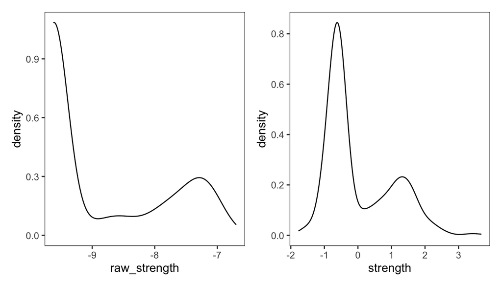

```r
p1 = pretest %>%
    ggplot(aes(raw_strength)) +
    geom_density()

p2 = pretest %>%
    ggplot(aes(strength)) +
    geom_density()

p1 + p2
```

This measure is combining two really different sorts of thing: accuracy and reaction time. As we see below, both are independently predictive of test performance.

# Predicting response

Note: In all the plots below, “RT” is actually z-scored log reaction time. Z-scoring respects response type. For pretest trials, the z-scoring is only done on correct trials (we don’t use error RTs). For critical trials, z-scoring is done separately on correct and skip trials (we throw out other trials).

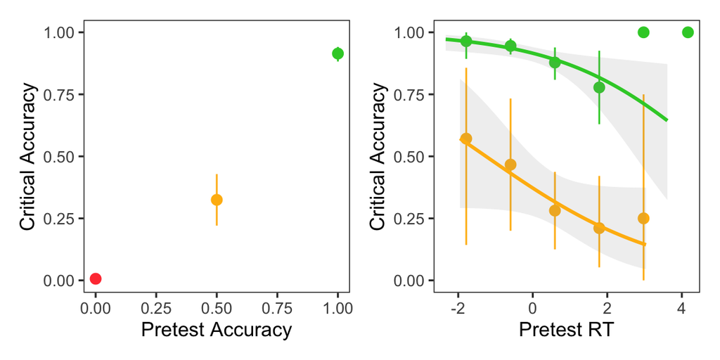

```r
pal = scale_colour_manual(values=c(
    `0`="brown1",
    `0.5`="darkgoldenrod1",
    `1`="limegreen"
), aesthetics=c("fill", "colour"))

p1 = trials %>%
    ggplot(aes(pre_correct, 1*correct, color=factor(pre_correct))) +
    stat_summary(fun.data=mean_cl_boot) +
    guides(color="none") +
    pal + labs(x='Pretest Accuracy', y='Critical Accuracy')

p2 = trials %>%
    ggplot(aes(pre_logrt_z, 1*correct, color=factor(pre_correct))) +
    stat_summary_bin(fun.data=mean_cl_boot, bins=5) +
    geom_smooth(method = "glm", method.args = list(family = "binomial"), formula=y~x, alpha=.15) +
    pal + labs(x='Pretest RT', y='Critical Accuracy')

(p1 + p2) & theme(legend.position='none') & coord_cartesian(xlim=c(NULL), ylim=c(0, 1))
```

Both accuracy and reaction time in the pretest predicts responding correctly vs. skipping, in the way you’d expect.

# Predicting RT on correct trials

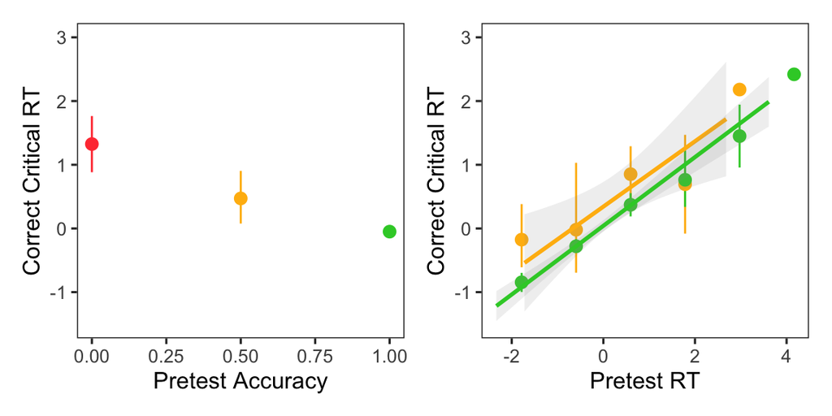

```r
p1 = trials %>%
    filter(correct) %>%
    group_by(wid) %>%
    mutate(logrt_z = zscore(log(rt))) %>%
    ggplot(aes(pre_correct, logrt_z, color=factor(pre_correct))) +
    stat_summary(fun.data=mean_cl_boot) +
    pal + labs(x='Pretest Accuracy', y='Correct Critical RT')

p2 = trials %>%
    filter(correct) %>%
    group_by(wid) %>%
    mutate(logrt_z = zscore(log(rt))) %>%
    ggplot(aes(pre_logrt_z, logrt_z, color=factor(pre_correct))) +
    stat_summary_bin(fun.data=mean_cl_boot, bins=5) +
    geom_smooth(method="lm", alpha=0.15) +
    pal + labs(x='Pretest RT', y='Correct Critical RT')

(p1 + p2) & theme(legend.position='none') & coord_cartesian(xlim=c(NULL), ylim=c(-1.5, 3))
```

Both accuracy and reaction time in the pretest predicts speed of correct trials, again, in the way you’d expect. It is noteworthy that accuracy better predicts accuracy and RT better predicts RT.

# Predicting RT on skips

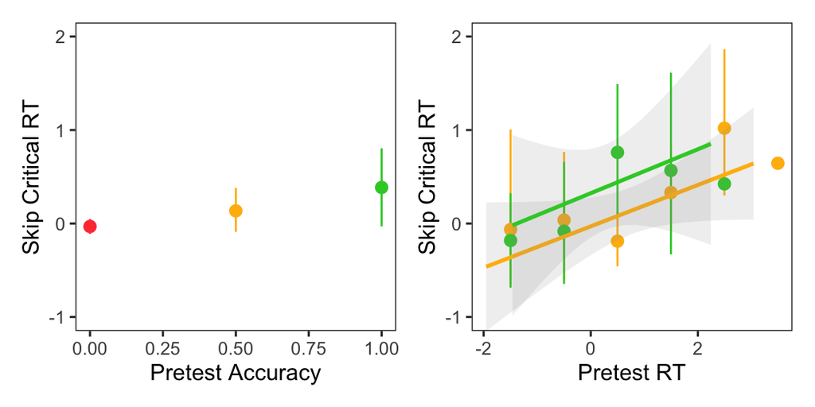

```r
p1 = trials %>%
    filter(skip) %>%
    group_by(wid) %>%
    mutate(logrt_z = zscore(log(rt))) %>%
    ggplot(aes(pre_correct, logrt_z, color=factor(pre_correct))) +
    stat_summary(fun.data=mean_cl_boot) +
    theme(legend.position="none") + pal +
    labs(x='Pretest Accuracy', y='Skip Critical RT')

p2 = trials %>%
    filter(skip) %>%
    group_by(wid) %>%
    mutate(logrt_z = zscore(log(rt))) %>%
    # mutate(pre_logrt_z = zscore(pre_logrt)) %>%
    ggplot(aes(pre_logrt_z, logrt_z, color=factor(pre_correct))) +
    stat_summary_bin(fun.data=mean_cl_boot, bins=5) +
    geom_smooth(method="lm", alpha=0.15) +
    labs(x='Pretest RT', y='Skip Critical RT') + pal

(p1 + p2) & theme(legend.position='none') & coord_cartesian(xlim=c(NULL), ylim=c(-1, 2))
```

Pretest accuracy is behaving as we’d expect. People take longer to skip targets they recalled correctly in the pretest. But RT is in the opposite direction as predicted. We see a positive relationship, just as we did for correct trials. People take longer to skip on targets they took longer to recall in pretest.

How can we explain this? Recall that both RT measures are z-scored within participant, so it’s not something as simple as some people being generally slower than others. One possibility is that some images are more recognizable than others, leading to faster response times because actual memory recall starts sooner. This is a puzzle though.

## Regression

Can we dissociate the influence of each factor? Regression is tricky because pretest RT is undefined when both pretest trials were errors. The default is to just throw out those trials.

```r
trials %>%
    filter(skip) %>%
    group_by(wid) %>%
    mutate(logrt_z = zscore(log(rt))) %>%
    lmer(logrt_z ~ pre_logrt_z + pre_correct + (pre_logrt_z + pre_correct|wid), data=.) %>%
    summ
```

| Fixed Effects | Fixed Effects Est. | Fixed Effects S.E. | Fixed Effects t val. | Fixed Effects d.f. | Fixed Effects p |
| --- | --- | --- | --- | --- | --- |
| (Intercept) | -0.269 | 0.485 | -0.555 | 10.003 | 0.591 |
| pre_logrt_z | 0.205 | 0.108 | 1.895 | 54.437 | 0.063 |
| pre_correct | 0.682 | 0.673 | 1.013 | 11.082 | 0.333 |

p values calculated using Satterthwaite d.f.

However, this is throwing out the majority of skip trials, and it is reducing the range of pretest accuracy. An alternative is to replace the missing values with zero and add an extra dummy term to the regression for such cases. In effect, we let the model decide what it wants to replace a missing value with. This term also indicates that there was exactly zero pretest accuracy, so it could be capturing non-linearity in the effect of pretest acccuracy.

```r
trials %>%
    filter(skip) %>%
    mutate(no_prelogrt=1*is.na(pre_logrt_z)) %>%
    replace_na(list(pre_logrt_z=0)) %>%
    group_by(wid) %>%
    mutate(logrt_z = zscore(log(rt))) %>%
    # lm(logrt_z ~ pre_logrt_z + pre_correct + no_prelogrt, data=.) %>%
    lmer(logrt_z ~ pre_logrt_z + pre_correct + no_prelogrt + (pre_logrt_z + pre_correct |wid), data=.) %>%
    summ
```

| Fixed Effects | Fixed Effects Est. | Fixed Effects S.E. | Fixed Effects t val. | Fixed Effects d.f. | Fixed Effects p |
| --- | --- | --- | --- | --- | --- |
| (Intercept) | -0.599 | 0.378 | -1.585 | 182.919 | 0.115 |
| pre_logrt_z | 0.209 | 0.108 | 1.945 | 460.679 | 0.052 |
| pre_correct | 1.186 | 0.530 | 2.238 | 55.045 | 0.029 |
| no_prelogrt | 0.568 | 0.380 | 1.496 | 185.917 | 0.136 |

p values calculated using Satterthwaite d.f.

# Conclusion

I don’t know exactly what to conclude from this. I do think that continuing to use our “memory strength” index is not a good path forward. The easiest solution would be to just ignore RT and use pretest accuracy as a discrete strength measurement. But this makes me feel a bit uneasy, as it is basically hiding the way that the data and model are inconsistent.